# Доклад по лабораторной работе №5

Дискреционное разграничение прав в Linux. Исследование влияния дополнительных атрибутов

Архипов Александр Сергеевич

НБИбд-01-24

1132239106 | 1132239106@rudn.ru

07.10.2026

# Цели и задачи

## Теоретическое введение

- SUID - разрешение на установку идентификатора пользователя. Это бит разрешения, который позволяет пользователю запускать исполняемый файл с правами владельца этого файла.
- SGID - разрешение на установку идентификатора группы. Принцип работы очень похож на SUID с отличием, что файл будет запускаться пользователем от имени группы, которая владеет файлом.

## Цель лабораторной работы

Изучение механизмов изменения идентификаторов, применения SetUID и Sticky-битов. Получение практических навыков работы в консоли с дополнительными атрибутами. Рассмотрение работы механизма смены идентификатора процессов пользователей, а также влияние бита Sticky на запись и удаление файлов.

# Выполнение лабораторной работы

## Программа simpleid

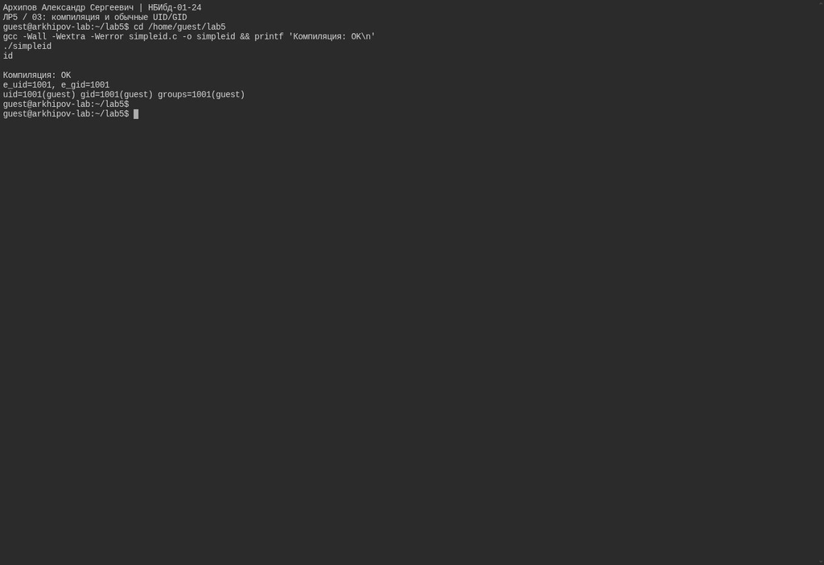

компиляция и обычные UID/GID

## Программа simpleid2

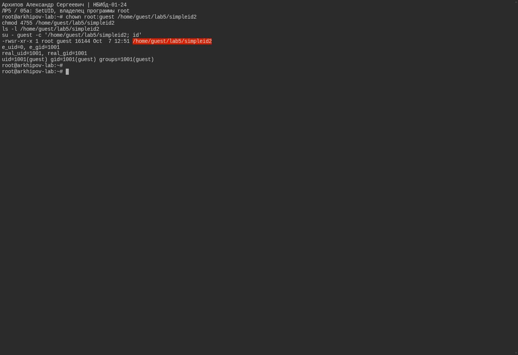

SetUID, владелец программы root

## Программа readfile

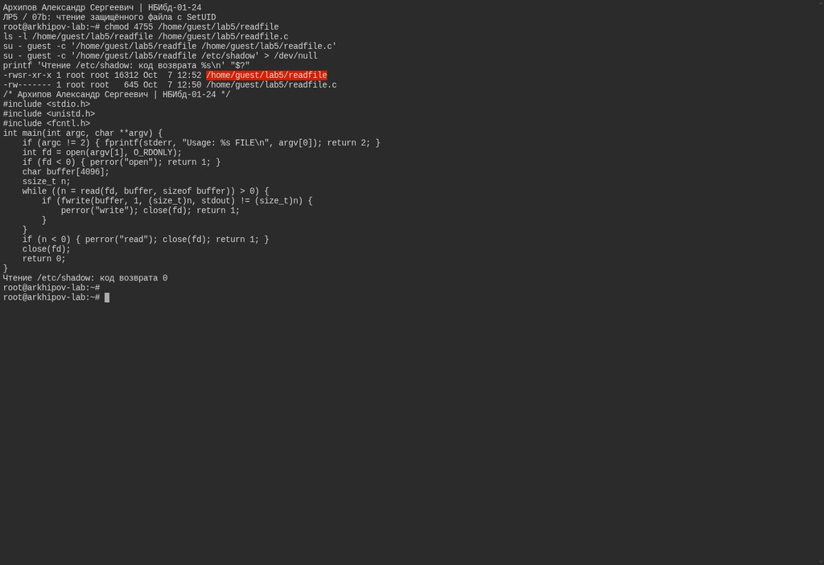

чтение защищённого файла с SetUID

## Исследование Sticky-бита

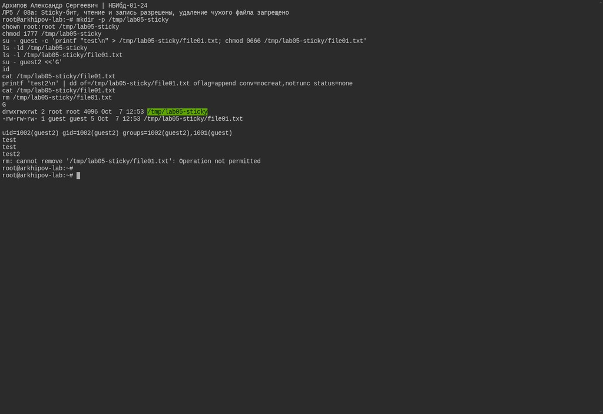

Sticky-бит, чтение и запись разрешены, удаление чужого файла запрещено

## Среда выполнения

Работа выполнена в Ubuntu 24.04 с GCC 13.3. Здесь активен AppArmor, SELinux не включён: этап setenforce 0 / Permissive не выполнялся. Опыты с UID/GID, SetUID/SetGID и Sticky-битом выполнены реально. Для Sticky-бита использован отдельный каталог /tmp/lab05-sticky; глобальные права /tmp не изменялись. После опытов временные SetUID/SetGID сняты, каталог восстановлен в режиме 1777.

## компилятор и фактическое окружение

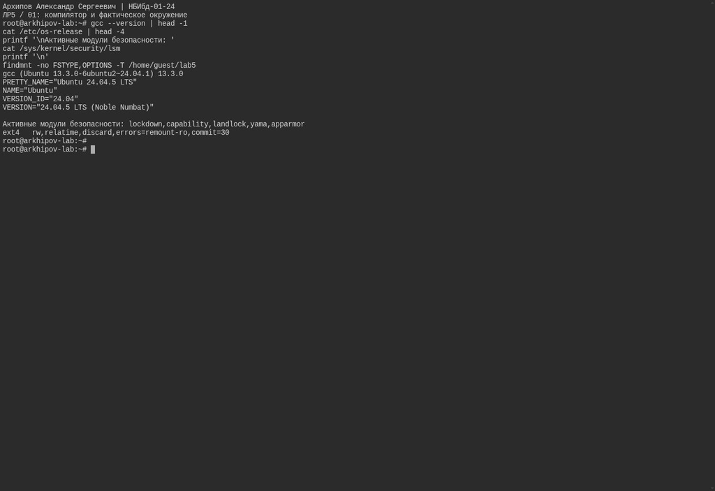

компилятор и фактическое окружение

## исходный код simpleid.c

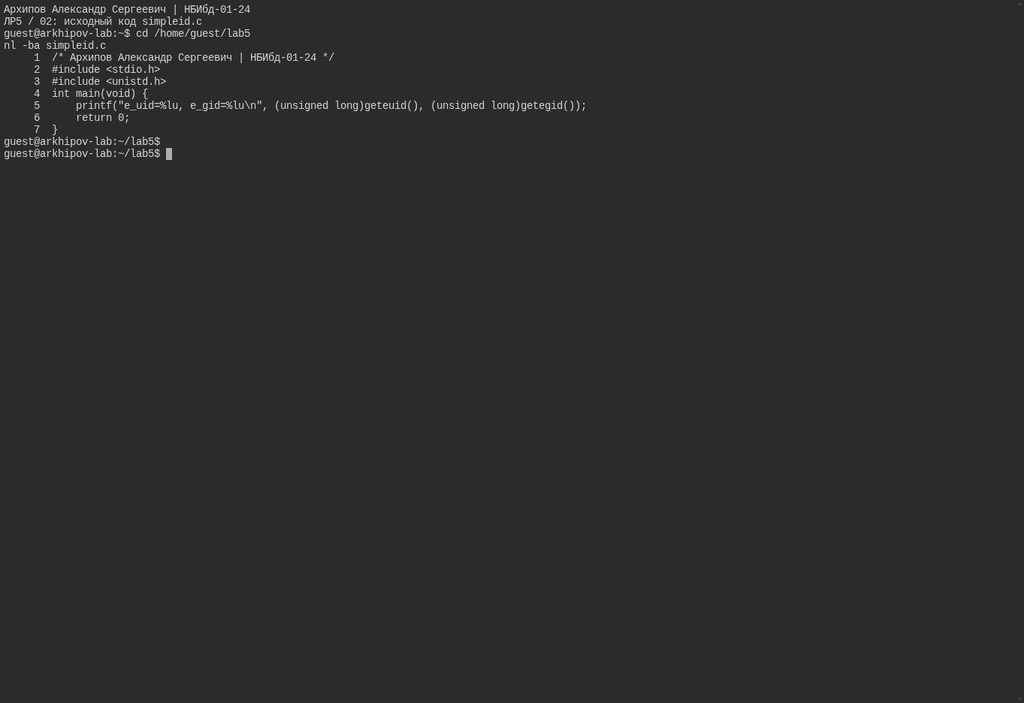

исходный код simpleid.c

## исходник с real и effective UID/GID

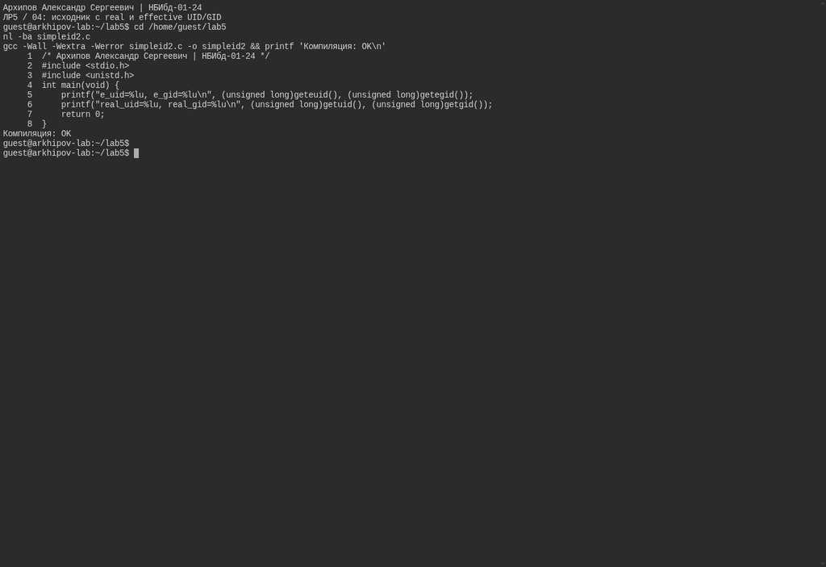

исходник с real и effective UID/GID

## SetGID, группа программы root

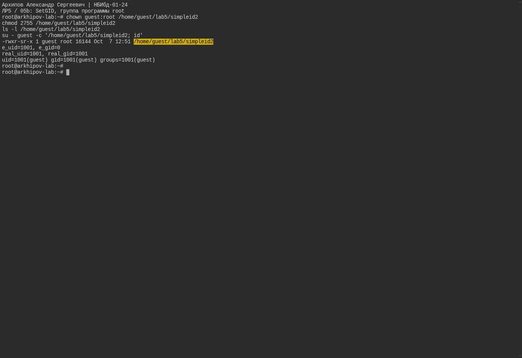

SetGID, группа программы root

## исправленный исходник readfile.c

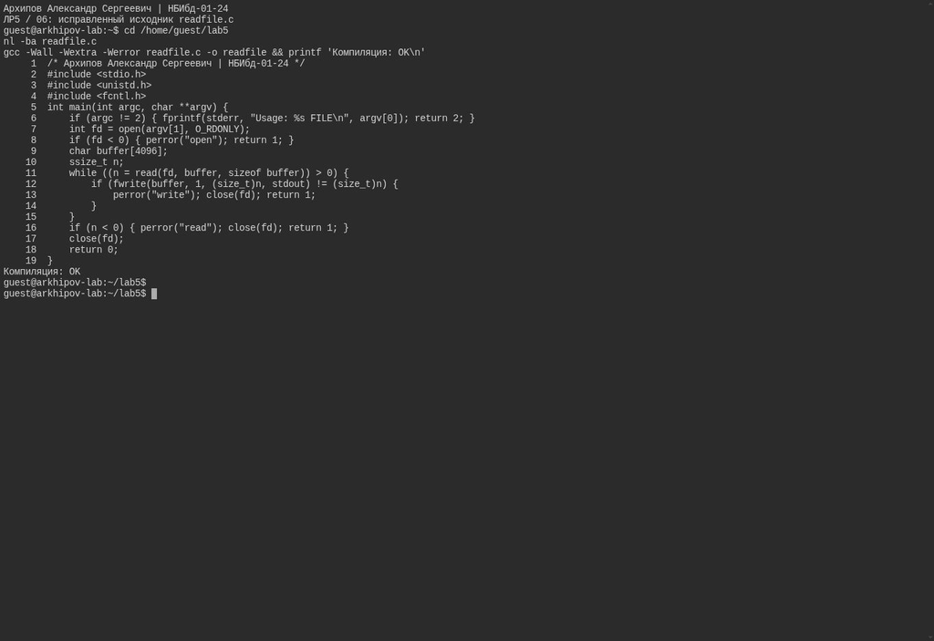

исправленный исходник readfile.c

## чтение root-файла без SetUID

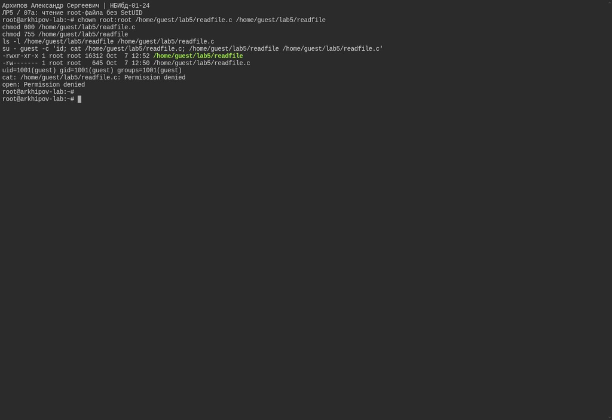

чтение root-файла без SetUID

## снятие Sticky-бита и восстановление 1777

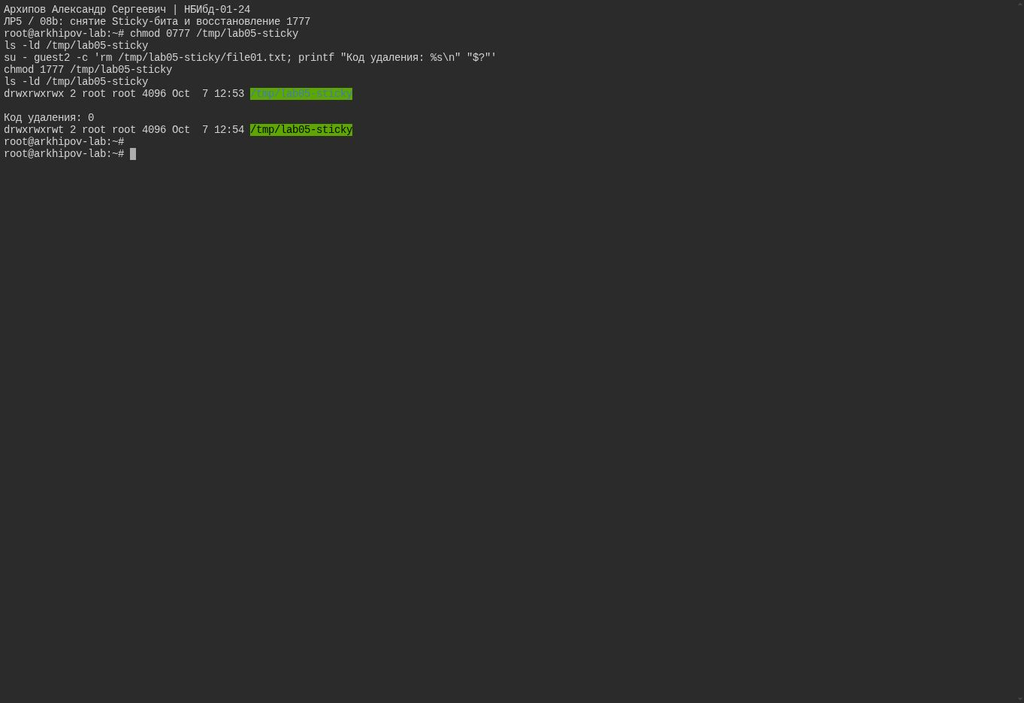

снятие Sticky-бита и восстановление 1777

# Выводы

## Результаты выполнения лабораторной работы

Изучили механизмы изменения идентификаторов, применения SetUID- и Sticky-битов. Получили практические навыки работы в консоли с дополнительными атрибутами. Также мы рассмотрели работу механизма смены идентификатора процессов пользователей и влияние бита Sticky на запись и удаление файлов.